# 1. Load libraries

```python
# Import all the libraries
import numpy as np
import pandas as pd
import matplotlib.pyplot as plt
import seaborn as sns
```

# 2. Load Data

```python
df = pd.read_csv("bank-full.csv", sep = ';')
df.shape
```

```
(45211, 17)
```

```python
df.head()
```

|  | age | job | marital | education | default | balance | housing | loan | contact | day | month | duration | campaign | pdays | previous | poutcome | y |
| --- | --- | --- | --- | --- | --- | --- | --- | --- | --- | --- | --- | --- | --- | --- | --- | --- | --- |
| 0 | 58 | management | married | tertiary | no | 2143 | yes | no | unknown | 5 | may | 261 | 1 | -1 | 0 | unknown | no |
| 1 | 44 | technician | single | secondary | no | 29 | yes | no | unknown | 5 | may | 151 | 1 | -1 | 0 | unknown | no |
| 2 | 33 | entrepreneur | married | secondary | no | 2 | yes | yes | unknown | 5 | may | 76 | 1 | -1 | 0 | unknown | no |
| 3 | 47 | blue-collar | married | unknown | no | 1506 | yes | no | unknown | 5 | may | 92 | 1 | -1 | 0 | unknown | no |
| 4 | 33 | unknown | single | unknown | no | 1 | no | no | unknown | 5 | may | 198 | 1 | -1 | 0 | unknown | no |

# 3. Exploratory Data Analysis

## 3.1 Understand Column Labels

```python
# Rename Columns Names to more informative name
df = df.rename(columns = {'marital':'marital_Status', 'y':'subscribed'})
```

```python
# Capitalize the first letter column names
df.columns = [col.capitalize() for col in df.columns]
```

```python
# Datatypes information
df.info()
```

```
<class 'pandas.core.frame.DataFrame'>
RangeIndex: 45211 entries, 0 to 45210
Data columns (total 17 columns):
 #   Column          Non-Null Count  Dtype
---  ------          --------------  -----
 0   Age             45211 non-null  int64
 1   Job             45211 non-null  object
 2   Marital_status  45211 non-null  object
 3   Education       45211 non-null  object
 4   Default         45211 non-null  object
 5   Balance         45211 non-null  int64
 6   Housing         45211 non-null  object
 7   Loan            45211 non-null  object
 8   Contact         45211 non-null  object
 9   Day             45211 non-null  int64
 10  Month           45211 non-null  object
 11  Duration        45211 non-null  int64
 12  Campaign        45211 non-null  int64
 13  Pdays           45211 non-null  int64
 14  Previous        45211 non-null  int64
 15  Poutcome        45211 non-null  object
 16  Subscribed      45211 non-null  object
dtypes: int64(7), object(10)
memory usage: 5.9+ MB
```

### Based on the data, here's what each column appears to represent:

- **Age :** --> Age(numeric)
- **Job :** --> type of job (categorical: "admin.","unknown","unemployed","management","housemaid","entrepreneur","student",

  ```
                     "blue-collar","self-employed","retired","technician","services")
  ```

- **marital: Marital_Status** --> marital status (categorical: "married","divorced","single"; note: "divorced" means divorced or widowed)
- **Education :** --> Education Levels (categorical: "unknown","secondary","primary","tertiary")
- **Default:** --> has credit in default? (binary: "yes","no")
- **Balance:** --> average yearly balance, in euros (numeric)
- **Housing:** --> has housing loan? (binary: "yes","no")
- **Loan:** --> has personal loan? (binary: "yes","no")

#### Related with the last contact of the current campaign:

- **Contact:** --> contact communication type (categorical: "unknown","telephone","cellular")
- **Day:** --> last contact day of the month (numeric)
- **Month:** --> last contact month of year (categorical: "jan", "feb", "mar", ..., "nov", "dec")
- **Duration:** --> last contact duration, in seconds (numeric)

#### Other attributes:

- **Campaign:** --> number of contacts performed during this campaign and for this client (numeric, includes last contact)
- **Pdays:** --> number of days that passed by after the client was last contacted from a previous campaign (numeric, -1 means client was not previously contacted)
- **Previous:** --> number of contacts performed before this campaign and for this client (numeric)
- **Poutcome:** --> outcome of the previous marketing campaign (categorical: "unknown","other","failure","success")

#### Output variable (desired target):

- **y: Subscribed** --> has the client subscribed a term deposit? (binary: "yes","no")

## 3.2 Correct Datatypes

```python
# Changing Default column from categorical to binary numerical
df['Default'] = df['Default'].replace({'yes':1, 'no':0})
```

```python
# Encoding Month Column with numerical values
month_mapping = {
    'jan': 1,
    'feb': 2,
    'mar': 3,
    'apr': 4,
    'may': 5,
    'jun': 6,
    'jul': 7,
    'aug': 8,
    'sep': 9,
    'oct': 10,
    'nov': 11,
    'dec': 12
}

df['Month'] = df['Month'].replace(month_mapping)
```

## 3.3 Handle Missing Values and Duplicate values

```python
missing_data = df.isnull()
```

```python
# Count missing values
for column in missing_data.columns.values.tolist():
    print(column)
    print (missing_data[column].value_counts())
    print("")
```

```
Age
False    45211
Name: Age, dtype: int64

Job
False    45211
Name: Job, dtype: int64

Marital_status
False    45211
Name: Marital_status, dtype: int64

Education
False    45211
Name: Education, dtype: int64

Default
False    45211
Name: Default, dtype: int64

Balance
False    45211
Name: Balance, dtype: int64

Housing
False    45211
Name: Housing, dtype: int64

Loan
False    45211
Name: Loan, dtype: int64

Contact
False    45211
Name: Contact, dtype: int64

Day
False    45211
Name: Day, dtype: int64

```

[output cut: 12 more lines]

```
Pdays
False    45211
Name: Pdays, dtype: int64

Previous
False    45211
Name: Previous, dtype: int64

Poutcome
False    45211
Name: Poutcome, dtype: int64

Subscribed
False    45211
Name: Subscribed, dtype: int64
```

```python
#Check for duplicates
duplicates = df.duplicated()
count_duplicates = duplicates.sum()

print(duplicates)
print("Number of duplicate rows:", count_duplicates)
```

```
0        False
1        False
2        False
3        False
4        False
         ...
45206    False
45207    False
45208    False
45209    False
45210    False
Length: 45211, dtype: bool
Number of duplicate rows: 0
```

## 3.4 Statistical Analysis

```python
print ("Rows     : " ,df.shape[0])
print ("Columns  : " ,df.shape[1])
print ("\nFeatures : \n" ,df.columns.tolist())
print ("\nUnique values :  \n",df.nunique())
```

```
Rows     :  45211
Columns  :  17

Features :
 ['Age', 'Job', 'Marital_status', 'Education', 'Default', 'Balance', 'Housing', 'Loan', 'Contact', 'Day', 'Month', 'Duration', 'Campaign', 'Pdays', 'Previous', 'Poutcome', 'Subscribed']

Unique values :
 Age                 77
Job                 12
Marital_status       3
Education            4
Default              2
Balance           7168
Housing              2
Loan                 2
Contact              3
Day                 31
Month               12
Duration          1573
Campaign            48
Pdays              559
Previous            41
Poutcome             4
Subscribed           2
dtype: int64
```

```python
df.head().T
```

|  | 0 | 1 | 2 | 3 | 4 |
| --- | --- | --- | --- | --- | --- |
| Age | 58 | 44 | 33 | 47 | 33 |
| Job | management | technician | entrepreneur | blue-collar | unknown |
| Marital_status | married | single | married | married | single |
| Education | tertiary | secondary | secondary | unknown | unknown |
| Default | 0 | 0 | 0 | 0 | 0 |
| Balance | 2143 | 29 | 2 | 1506 | 1 |
| Housing | yes | yes | yes | yes | no |
| Loan | no | no | yes | no | no |
| Contact | unknown | unknown | unknown | unknown | unknown |
| Day | 5 | 5 | 5 | 5 | 5 |
| Month | 5 | 5 | 5 | 5 | 5 |
| Duration | 261 | 151 | 76 | 92 | 198 |
| Campaign | 1 | 1 | 1 | 1 | 1 |
| Pdays | -1 | -1 | -1 | -1 | -1 |
| Previous | 0 | 0 | 0 | 0 | 0 |
| Poutcome | unknown | unknown | unknown | unknown | unknown |
| Subscribed | no | no | no | no | no |

```python
df.describe()
```

|  | Age | Default | Balance | Day | Month | Duration | Campaign | Pdays | Previous |
| --- | --- | --- | --- | --- | --- | --- | --- | --- | --- |
| count | 45211.000000 | 45211.000000 | 45211.000000 | 45211.000000 | 45211.000000 | 45211.000000 | 45211.000000 | 45211.000000 | 45211.000000 |
| mean | 40.936210 | 0.018027 | 1362.272058 | 15.806419 | 6.144655 | 258.163080 | 2.763841 | 40.197828 | 0.580323 |
| std | 10.618762 | 0.133049 | 3044.765829 | 8.322476 | 2.408034 | 257.527812 | 3.098021 | 100.128746 | 2.303441 |
| min | 18.000000 | 0.000000 | -8019.000000 | 1.000000 | 1.000000 | 0.000000 | 1.000000 | -1.000000 | 0.000000 |
| 25% | 33.000000 | 0.000000 | 72.000000 | 8.000000 | 5.000000 | 103.000000 | 1.000000 | -1.000000 | 0.000000 |
| 50% | 39.000000 | 0.000000 | 448.000000 | 16.000000 | 6.000000 | 180.000000 | 2.000000 | -1.000000 | 0.000000 |
| 75% | 48.000000 | 0.000000 | 1428.000000 | 21.000000 | 8.000000 | 319.000000 | 3.000000 | -1.000000 | 0.000000 |
| max | 95.000000 | 1.000000 | 102127.000000 | 31.000000 | 12.000000 | 4918.000000 | 63.000000 | 871.000000 | 275.000000 |

## 3.5 Numerical Analysis - Search for outliers

```python
#Separating Default and non Default customers

Default     = df[df["Default"] == 1]
Not_Default = df[df["Default"] == 0]

print ('Customers who are not Defaulters', len(Not_Default))
print ('Customers who are Defaulters', len(Default))
```

```
Customers who are not Defaulters 44396
Customers who are Defaulters 815
```

```python
# Convert Age column to categorical column
def age_lab(df) :

    if df["Age"] <= 20 :
        return "Age_0-20"
    elif (df["Age"] > 20) & (df["Age"] <= 40 ):
        return "Age_21-40"
    elif (df["Age"] > 40) & (df["Age"] <= 60) :
        return "Age_41-60"
    elif (df["Age"] > 60) & (df["Age"] <= 80) :
        return "Age_61-80"
    elif df["Age"] > 80 :
        return "Age_gt_80"

df["Age_group"] = df.apply(lambda df:age_lab(df),
                                      axis = 1)
```

```python
df['Age_group'].unique()
```

```
array(['Age_41-60', 'Age_21-40', 'Age_61-80', 'Age_0-20', 'Age_gt_80'],
      dtype=object)
```

```python
# separate numerical columns
num_cols = df.select_dtypes(include = 'number')
num_cols.keys().tolist()
```

```
['Age',
 'Default',
 'Balance',
 'Day',
 'Month',
 'Duration',
 'Campaign',
 'Pdays',
 'Previous']
```

```python
# seperate target column
target_col = ["Subscribed"]
```

```python
# separate category columns
cat_cols = df.select_dtypes(include = 'object')
cat_cols.keys().tolist()
```

```
['Job',
 'Marital_status',
 'Education',
 'Housing',
 'Loan',
 'Contact',
 'Poutcome',
 'Subscribed',
 'Age_group']
```

```python
num_cols = [col.strip() for col in num_cols]
num_cols
```

```
['Age',
 'Default',
 'Balance',
 'Day',
 'Month',
 'Duration',
 'Campaign',
 'Pdays',
 'Previous']
```

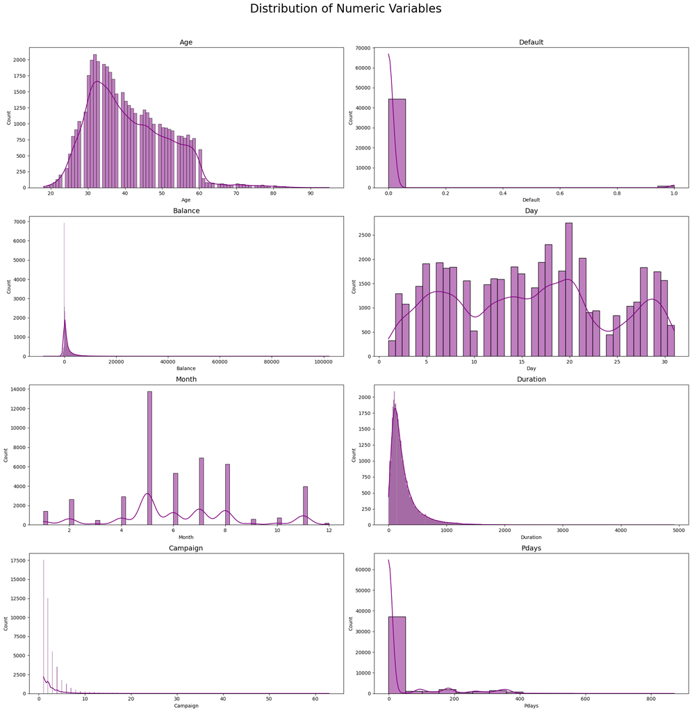

```python
import seaborn as sns
import matplotlib.pyplot as plt

fig, axes = plt.subplots(4, 2, figsize=(20, 20))
fig.suptitle("Distribution of Numeric Variables", size=24, y=1.02)
fig.subplots_adjust(hspace=0.5, wspace=0.2)

for i in range(4):
    for j in range(2):
        index = 2 * i + j
        if index < len(num_cols):
            sns.histplot(df[num_cols[index]], ax=axes[i, j], kde=True, color='purple')
            axes[i, j].set_title(num_cols[index], size=14)
        else:
            axes[i, j].axis('off')

plt.tight_layout()
plt.show()
```

The exploration of bank marketing data uncovers insightful information, focusing on key features such as Age, Default Status, Average Account Balance, Last Contact Day in the Month, Last Contact Month of the Year, Last Contact Duration, Campaign, and Previous Contact Days since the last campaign. As we analyze the distribution of these numerical variables using histograms, noteworthy observations emerge:

**1. Age**: The concentration of customers in the 30 to 40 years age group suggests that the bank's marketing efforts may be particularly resonating with individuals in this demographic. Understanding the characteristics and preferences of this age group could be crucial for targeted marketing strategies.

**2. Default**: The dataset predominantly consists of non-defaulters, with around 45,000 customers marked as "No" and approximately 1,000 customers marked as "Yes" for default status.This imbalance suggests that the majority of customers in the dataset have a non-default status. Understanding the characteristics and factors influencing defaulters could be crucial for risk assessment and targeted financial strategies.

**3.Balance**: The majority of customers in the dataset have an account balance that falls below 5000 units.suggests that a significant portion of the customer base maintains relatively lower account balances. This insight could inform targeted financial services or promotions tailored to the needs of customers with varying balance levels.

**4.Last Contact Day:** The peak count of 2,700 occurs for contacts made on the 20th day of the month. This concentration may indicate a strategic focus on the 20th day for conducting outreach or marketing campaigns. Understanding the effectiveness of interactions on this specific day could provide valuable insights into customer engagement patterns.

**5.Last Contact Month of the Year**: The dataset reflects a substantial count, with approximately 14,000 records corresponding to the 5th month. This observation suggests a notable emphasis on customer interactions and marketing activities during the 5th month of the year.

**6.Last Contact Duration**: The majority of last contact durations fall within the range of 0 to 1000 seconds. This concentration indicates that a significant portion of customer interactions is relatively short in duration.

**7.Campaign**: The data reveals that the highest count of contacts performed during this campaign and for this client is in the range of 1 to 5. This observation suggests that a substantial number of clients were contacted relatively fewer times during the campaign, potentially indicating a focused and targeted outreach strategy. Understanding the impact of the number of contacts on campaign success is crucial for refining future engagement approaches.

## 3.6 Numerical Analysis Without Outliers

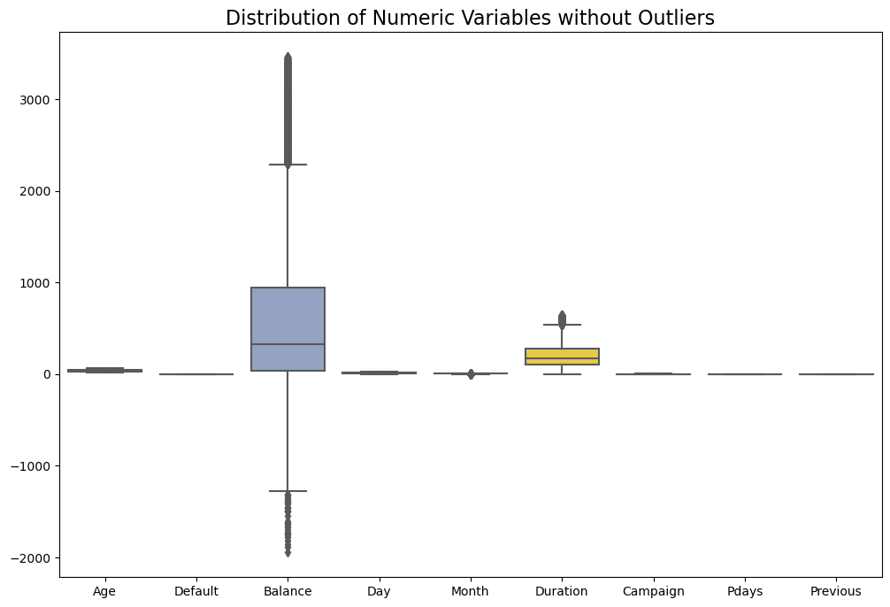

```python
# Create a new DataFrame to store data without outliers
df_no_outliers = df.copy()

# Loop through numeric columns and remove outliers
for col in num_cols:
    # Calculate IQR
    Q1 = df[col].quantile(0.25)
    Q3 = df[col].quantile(0.75)
    IQR = Q3 - Q1

    # Define upper and lower bounds to filter outliers
    lower_bound = Q1 - 1.5 * IQR
    upper_bound = Q3 + 1.5 * IQR

    # Remove outliers
    df_no_outliers = df_no_outliers[(df_no_outliers[col] >= lower_bound) & (df_no_outliers[col] <= upper_bound)]

# Visualize the distribution of numeric variables without outliers
plt.figure(figsize=(12, 8))
sns.boxplot(data=df_no_outliers[num_cols], palette='Set2')
plt.title("Distribution of Numeric Variables without Outliers", size=16)
plt.show()
```

- Here, we first calculate Q1 and Q3 using the quantile method. Then, we compute the IQR, and based on your specified rules, we calculate the lower and upper bounds for potential outliers. Finally, we create the boxplot, highlighting data points that fall outside these bounds, effectively showing potential outliers.

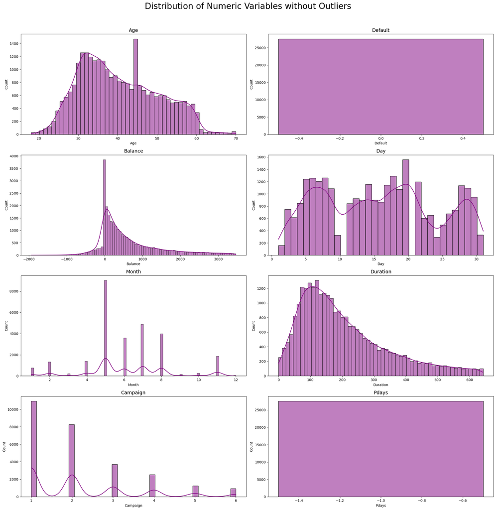

```python
import seaborn as sns
import matplotlib.pyplot as plt

fig, axes = plt.subplots(4, 2, figsize=(20, 20))
fig.suptitle("Distribution of Numeric Variables without Outliers", size=24, y=1.02)
fig.subplots_adjust(hspace=0.5, wspace=0.2)

for i in range(4):
    for j in range(2):
        index = 2 * i + j
        if index < len(num_cols):
            sns.histplot(df_no_outliers[num_cols[index]], ax=axes[i, j], kde=True, color='purple')
            axes[i, j].set_title(num_cols[index], size=14)
        else:
            axes[i, j].axis('off')

plt.tight_layout()
plt.show()
```

```python
df.info()
```

```
<class 'pandas.core.frame.DataFrame'>
RangeIndex: 45211 entries, 0 to 45210
Data columns (total 18 columns):
 #   Column          Non-Null Count  Dtype
---  ------          --------------  -----
 0   Age             45211 non-null  int64
 1   Job             45211 non-null  object
 2   Marital_status  45211 non-null  object
 3   Education       45211 non-null  object
 4   Default         45211 non-null  int64
 5   Balance         45211 non-null  int64
 6   Housing         45211 non-null  object
 7   Loan            45211 non-null  object
 8   Contact         45211 non-null  object
 9   Day             45211 non-null  int64
 10  Month           45211 non-null  int64
 11  Duration        45211 non-null  int64
 12  Campaign        45211 non-null  int64
 13  Pdays           45211 non-null  int64
 14  Previous        45211 non-null  int64
 15  Poutcome        45211 non-null  object
 16  Subscribed      45211 non-null  object
 17  Age_group       45211 non-null  object
dtypes: int64(9), object(9)
memory usage: 6.2+ MB
```

## 3.7 Categorical Analysis

```python
df.Marital_status.value_counts()
```

```
married     27214
single      12790
divorced     5207
Name: Marital_status, dtype: int64
```

```python
df.Education.value_counts()
```

```
secondary    23202
tertiary     13301
primary       6851
unknown       1857
Name: Education, dtype: int64
```

```python
df.Job.value_counts()
```

```
blue-collar      9732
management       9458
technician       7597
admin.           5171
services         4154
retired          2264
self-employed    1579
entrepreneur     1487
unemployed       1303
housemaid        1240
student           938
unknown           288
Name: Job, dtype: int64
```

```python
df.Education.value_counts()
```

```
secondary    23202
tertiary     13301
primary       6851
unknown       1857
Name: Education, dtype: int64
```

```python
df.Housing.value_counts()
```

```
yes    25130
no     20081
Name: Housing, dtype: int64
```

```python
df.Default.value_counts()
```

```
0    44396
1      815
Name: Default, dtype: int64
```

```python
df.Subscribed.value_counts()
```

```
no     39922
yes     5289
Name: Subscribed, dtype: int64
```

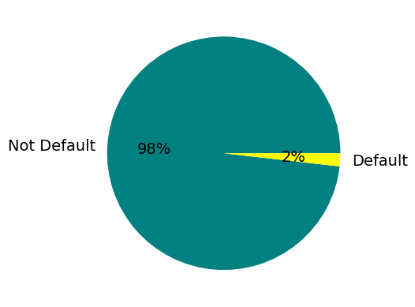

```python
# Plot a pie chart of the Default column distribution
plt.pie(df.Default.value_counts(),labels = ["Not Default", "Default"],
        colors = ["teal", "yellow"], autopct='%.0f%%', textprops={'fontsize': 14})
plt.show()
```

- The dataset exhibits a significant class imbalance, with non-defaulters constituting 98% and defaulters making up 2%. This imbalance poses challenges for predictive modeling, requiring careful consideration of evaluation metrics and potential strategies to address the skewed distribution.
- Focused analysis on the minority class (defaulters) is essential for gaining insights into their characteristics and improving model performance.

## 3.8 Analysis Between Dependent and Independent Variables

```
Dominant category in 'Job': blue-collar
Dominant category in 'Marital_status': married
Dominant category in 'Education': secondary
Dominant category in 'Housing': yes
Dominant category in 'Loan': no
Dominant category in 'Contact': cellular
Dominant category in 'Poutcome': unknown
Dominant category in 'Age_group': Age_21-40
```

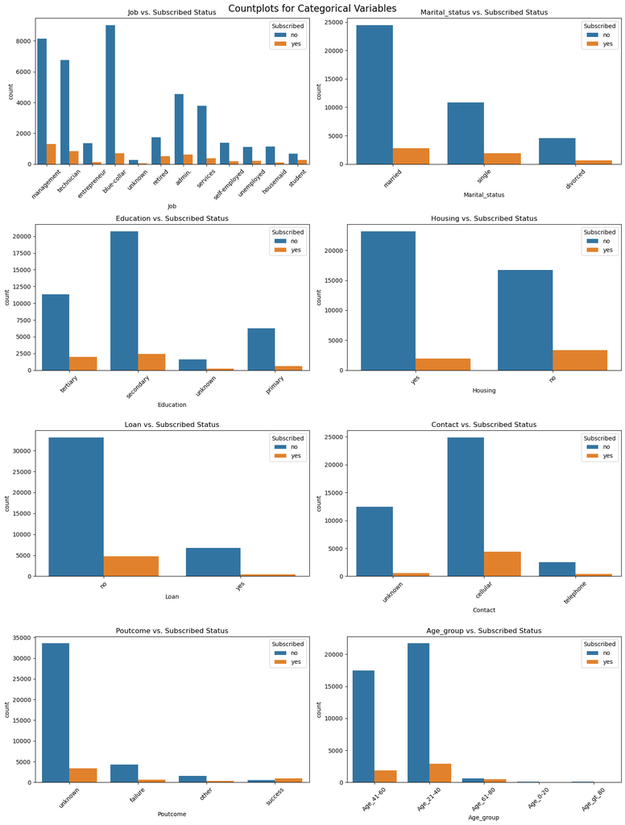

```python
# Assuming cat_cols contains the categorical columns you want to visualize
cat_cols = ['Job', 'Marital_status', 'Education', 'Housing', 'Loan', 'Contact', 'Poutcome', 'Age_group']

# Calculate the number of rows and columns for subplots based on the number of categorical columns
num_rows = (len(cat_cols) + 1) // 2  # Ensure at least one row
num_cols = min(2, len(cat_cols))  # Maximum 2 columns for better layout

# Create a figure and subplots
fig, axes = plt.subplots(num_rows, num_cols, figsize=(15, 5 * num_rows))

# Flatten the axes array if there's only one row
axes = axes.flatten() if num_rows > 1 else [axes]

# Loop through categorical columns and create countplots
for i, cat_col in enumerate(cat_cols):
    sns.countplot(data=df, x=cat_col, hue='Subscribed', ax=axes[i])
    axes[i].set_xticklabels(axes[i].get_xticklabels(), rotation=45)
    axes[i].set_title(f"{cat_col} vs. Subscribed Status")

    # Find the dominant category in each categorical column
    dominant_category = df[cat_col].value_counts().idxmax()
    print(f"Dominant category in '{cat_col}': {dominant_category}")

# Add a common title for all subplots
fig.suptitle('Countplots for Categorical Variables', size=16)

# Adjust spacing between subplots
plt.tight_layout()

# Show the plot
plt.show()
```

**1. Job Category Distribution:** *Dominant Category: blue-collar*

- Among customers who are not subscribed to a term deposit, the blue-collar job category is the most prevalent. This suggests that individuals in manual or industrial occupations show less interest in term deposits.

**2.Marital Status Distribution:** *Dominant Category: married*

- The countplot indicates that married individuals have a higher representation among those who subscribed to a term deposit. Understanding the marital status distribution helps tailor deposit offerings to different marital segments.

**3.Education Level Distribution:** *Dominant Category: secondary*

- The countplot shows that customers with a secondary education level are most abundant among those who subscribed to a term deposit. This insight is valuable for customizing communication and marketing strategies based on educational backgrounds for deposit products.

**4.Housing Loan Distribution:** *Dominant Category: yes*

- The countplot suggests that a significant number of customers with housing loans have not subscribed to a term deposit. This information is essential for financial institutions to assess the correlation between housing loans and term deposit subscriptions.

**5. Personal Loan Distribution:** *Dominant Category: no*

- The majority of customers who subscribed to a term deposit do not have personal loans. Understanding the prevalence of personal loans among subscribers assists in designing targeted deposit offerings.

**6.Contact Method Distribution:** *Dominant Category: cellular

- Among subscribers to term deposits, the cellular contact method is the most common. This insight is valuable for optimizing communication channels, particularly for marketing term deposit products.

**7.Previous Campaign Outcome Distribution:** *Dominant Category: unknown*

- The countplot shows that the outcome of the previous campaign is predominantly unknown among those who subscribed to a term deposit. Exploring and improving the tracking of campaign outcomes is crucial for refining future deposit-related strategies.

**8.Age Group Distribution:** *Dominant Category: Age_21-40*

- The countplot reveals that the age group between 21 and 40 years is the most represented among term deposit subscribers. Understanding the age distribution helps tailor term deposit products to different age demographics.

These insights specifically tailored to clients who have subscribed to a term deposit, offering a targeted perspective for strategic decision-making and marketing efforts related to deposit products.

# 4. Data Preprocessing Analysis

```python
df['Subscribed'] = df['Subscribed'].replace({'yes':1, 'no':0})
```

```python
import pandas as pd
from sklearn.preprocessing import LabelEncoder

# Categorical columns for one-hot encoding
one_hot_cols = ['Job', 'Marital_status', 'Education', 'Housing', 'Loan', 'Contact', 'Poutcome', 'Age_group']

# Binary columns for label encoding
label_encode_cols = ['Default']

# Create a copy of the original DataFrame
df_encoded = df.copy()

# One-hot encoding
df_encoded = pd.get_dummies(df_encoded, columns=one_hot_cols, drop_first=False)

# Label encoding for binary columns
label_encoder = LabelEncoder()
for col in label_encode_cols:
    df_encoded[col] = label_encoder.fit_transform(df_encoded[col])

# Display the first few rows of the encoded DataFrame
df_encoded.head().T
```

|  | 0 | 1 | 2 | 3 | 4 |
| --- | --- | --- | --- | --- | --- |
| Age | 58 | 44 | 33 | 47 | 33 |
| Default | 0 | 0 | 0 | 0 | 0 |
| Balance | 2143 | 29 | 2 | 1506 | 1 |
| Day | 5 | 5 | 5 | 5 | 5 |
| Month | 5 | 5 | 5 | 5 | 5 |
| Duration | 261 | 151 | 76 | 92 | 198 |
| Campaign | 1 | 1 | 1 | 1 | 1 |
| Pdays | -1 | -1 | -1 | -1 | -1 |
| Previous | 0 | 0 | 0 | 0 | 0 |
| Subscribed | 0 | 0 | 0 | 0 | 0 |
| Job_admin. | 0 | 0 | 0 | 0 | 0 |
| Job_blue-collar | 0 | 0 | 0 | 1 | 0 |
| Job_entrepreneur | 0 | 0 | 1 | 0 | 0 |
| Job_housemaid | 0 | 0 | 0 | 0 | 0 |
| Job_management | 1 | 0 | 0 | 0 | 0 |
| Job_retired | 0 | 0 | 0 | 0 | 0 |
| Job_self-employed | 0 | 0 | 0 | 0 | 0 |
| Job_services | 0 | 0 | 0 | 0 | 0 |
| Job_student | 0 | 0 | 0 | 0 | 0 |
| Job_technician | 0 | 1 | 0 | 0 | 0 |
| Job_unemployed | 0 | 0 | 0 | 0 | 0 |
| Job_unknown | 0 | 0 | 0 | 0 | 1 |
| Marital_status_divorced | 0 | 0 | 0 | 0 | 0 |
| Marital_status_married | 1 | 0 | 1 | 1 | 0 |
| Marital_status_single | 0 | 1 | 0 | 0 | 1 |
| Education_primary | 0 | 0 | 0 | 0 | 0 |
| Education_secondary | 0 | 1 | 1 | 0 | 0 |
| Education_tertiary | 1 | 0 | 0 | 0 | 0 |
| Education_unknown | 0 | 0 | 0 | 1 | 1 |
| Housing_no | 0 | 0 | 0 | 0 | 1 |
| Housing_yes | 1 | 1 | 1 | 1 | 0 |
| Loan_no | 1 | 1 | 0 | 1 | 1 |
| Loan_yes | 0 | 0 | 1 | 0 | 0 |
| Contact_cellular | 0 | 0 | 0 | 0 | 0 |
| Contact_telephone | 0 | 0 | 0 | 0 | 0 |
| Contact_unknown | 1 | 1 | 1 | 1 | 1 |
| Poutcome_failure | 0 | 0 | 0 | 0 | 0 |
| Poutcome_other | 0 | 0 | 0 | 0 | 0 |
| Poutcome_success | 0 | 0 | 0 | 0 | 0 |
| Poutcome_unknown | 1 | 1 | 1 | 1 | 1 |
| Age_group_Age_0-20 | 0 | 0 | 0 | 0 | 0 |
| Age_group_Age_21-40 | 0 | 0 | 1 | 0 | 1 |
| Age_group_Age_41-60 | 1 | 1 | 0 | 1 | 0 |
| Age_group_Age_61-80 | 0 | 0 | 0 | 0 | 0 |
| Age_group_Age_gt_80 | 0 | 0 | 0 | 0 | 0 |

# 5. Feature Scaling

```python
from sklearn.preprocessing import StandardScaler

# Extract numeric columns for standardization
numeric_cols = df_encoded.select_dtypes(include='number').columns

# Create a copy of the encoded DataFrame
df_standardized = df_encoded.copy()

# Initialize the StandardScaler
scaler = StandardScaler()

# Standardize the numeric columns
df_standardized[numeric_cols] = scaler.fit_transform(df_standardized[numeric_cols])

# Display the first few rows of the standardized DataFrame
df_standardized.head()
```

|  | Age | Default | Balance | Day | Month | Duration | Campaign | Pdays | Previous | Subscribed | ... | Contact_unknown | Poutcome_failure | Poutcome_other | Poutcome_success | Poutcome_unknown | Age_group_Age_0-20 | Age_group_Age_21-40 | Age_group_Age_41-60 | Age_group_Age_61-80 | Age_group_Age_gt_80 |
| --- | --- | --- | --- | --- | --- | --- | --- | --- | --- | --- | --- | --- | --- | --- | --- | --- | --- | --- | --- | --- | --- |
| 0 | 1.606965 | -0.13549 | 0.256419 | -1.298476 | -0.475354 | 0.011016 | -0.569351 | -0.411453 | -0.25194 | -0.363983 | ... | 1.572395 | -0.348687 | -0.205972 | -0.185948 | 0.472519 | -0.046369 | -1.093466 | 1.158366 | -0.157104 | -0.046846 |
| 1 | 0.288529 | -0.13549 | -0.437895 | -1.298476 | -0.475354 | -0.416127 | -0.569351 | -0.411453 | -0.25194 | -0.363983 | ... | 1.572395 | -0.348687 | -0.205972 | -0.185948 | 0.472519 | -0.046369 | -1.093466 | 1.158366 | -0.157104 | -0.046846 |
| 2 | -0.747384 | -0.13549 | -0.446762 | -1.298476 | -0.475354 | -0.707361 | -0.569351 | -0.411453 | -0.25194 | -0.363983 | ... | 1.572395 | -0.348687 | -0.205972 | -0.185948 | 0.472519 | -0.046369 | 0.914523 | -0.863285 | -0.157104 | -0.046846 |
| 3 | 0.571051 | -0.13549 | 0.047205 | -1.298476 | -0.475354 | -0.645231 | -0.569351 | -0.411453 | -0.25194 | -0.363983 | ... | 1.572395 | -0.348687 | -0.205972 | -0.185948 | 0.472519 | -0.046369 | -1.093466 | 1.158366 | -0.157104 | -0.046846 |
| 4 | -0.747384 | -0.13549 | -0.447091 | -1.298476 | -0.475354 | -0.233620 | -0.569351 | -0.411453 | -0.25194 | -0.363983 | ... | 1.572395 | -0.348687 | -0.205972 | -0.185948 | 0.472519 | -0.046369 | 0.914523 | -0.863285 | -0.157104 | -0.046846 |

5 rows × 45 columns

# 6. Machine Learning Modeling

```python
from sklearn.model_selection import train_test_split
from sklearn.ensemble import RandomForestClassifier
from sklearn.metrics import accuracy_score, classification_report, confusion_matrix

df_standardized['Subscribed'] = df_standardized['Subscribed'].astype(int)

# Features (X) and target variable (y)
X = df_standardized.drop('Subscribed', axis=1)
y = df_standardized['Subscribed']

# Split the data into training and testing sets
X_train, X_test, y_train, y_test = train_test_split(X, y, test_size=0.2, random_state=42)

# Initialize the Random Forest classifier
rf_classifier = RandomForestClassifier(n_estimators=100, random_state=42)

# Train the model
rf_classifier.fit(X_train, y_train)

# Make predictions on the test set
y_pred = rf_classifier.predict(X_test)

# Evaluate the model
accuracy = accuracy_score(y_test, y_pred)
conf_matrix = confusion_matrix(y_test, y_pred)
classification_rep = classification_report(y_test, y_pred)

# Print the results
print(f"Accuracy Score: {accuracy:.2f}")
print("\nConfusion Matrix:")
print(conf_matrix)
print("\nClassification Report:")
print(classification_rep)
```

[output not shown]

- The model has an overall accuracy of 90%, indicating strong performance. However, it shows challenges in correctly predicting instances where clients subscribed to a term deposit (class 1), with lower precision (66%) and recall (37%). The model excels in predicting instances where clients did not subscribe (class 0), with high precision (92%) and recall (97%).
- The imbalanced nature of the classes influences these results. Further refinement and exploration of techniques to address class imbalance may enhance model performance.

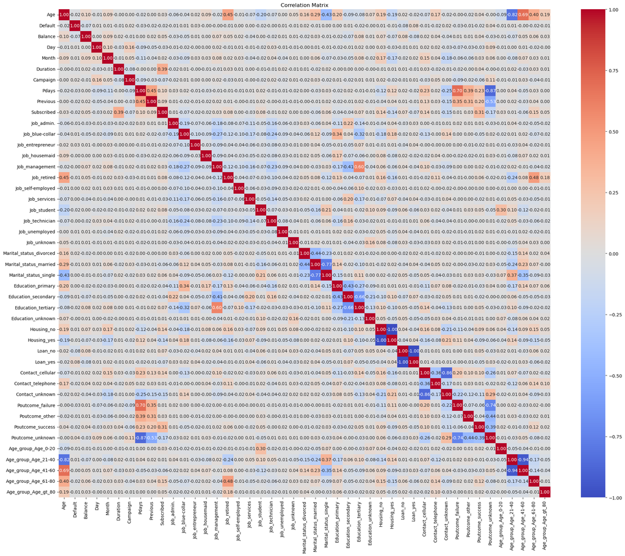

```python
# finding correlation between all the features
plt.figure(figsize=(25, 20))
correlation_matrix = df_standardized.corr()
sns.heatmap(correlation_matrix, annot=True, cmap="coolwarm", fmt=".2f")
plt.title('Correlation Matrix')
plt.show()
```

- A correlation matrix was generated to explore relationships between numerical features. This analysis revealed potential correlations that could impact model training.

# 7. Feature Importance Modeling

```python
#!pip install rfpimp
from rfpimp import *
I = importances(rf_classifier, X, y)
plot_importances(I, color='#4575b4')
```

[figure not shown]

```python
# Features (X) and target variable (y)
X = df_standardized.drop(['Subscribed','Default','Age_group_Age_gt_80', 'Age_group_Age_0-20','Poutcome_other','Job_retired','Job_housemaid',
                          'Job_unemployed','Age_group_Age_21-40', 'Job_unknown','Poutcome_unknown','Marital_status_divorced',
                          'Contact_telephone','Contact_telephone','Job_student', 'Education_unknown', 'Job_entrepreneur','Job_self-employed',
                          'Job_services', 'Job_technician', 'Job_management', 'Education_primary','Poutcome_failure','Age_group_Age_41-60',
                          'Age_group_Age_61-80','Job_admin.', 'Loan_yes','Loan_no','Education_secondary','Job_blue-collar', 'Previous'], axis=1)
y = df_standardized['Subscribed']

# Split the data into training and testing sets
X_train, X_test, y_train, y_test = train_test_split(X, y, test_size=0.2, random_state=42)

# Initialize the Random Forest classifier
rf_classifier = RandomForestClassifier(n_estimators=100, random_state=42)

# Train the model
rf_classifier.fit(X_train, y_train)

# Make predictions on the test set
y_pred = rf_classifier.predict(X_test)

# Evaluate the model
accuracy = accuracy_score(y_test, y_pred)
conf_matrix = confusion_matrix(y_test, y_pred)
classification_rep = classification_report(y_test, y_pred)

# Print the results
print(f"Accuracy Score: {accuracy:.2f}")
print("\nConfusion Matrix:")
print(conf_matrix)
print("\nClassification Report:")
print(classification_rep)
```

[output not shown]

- Despite conducting feature importance selection, the model's accuracy remains unchanged at 90%, indicating that the initial set of features already provided sufficient information for accurate predictions. The refinement in feature selection did not lead to a noticeable improvement in overall accuracy.

```python
I = importances(rf_classifier, X, y)
plot_importances(I, color='#4575b4')
```

[figure not shown]

```python
from sklearn.model_selection import GridSearchCV
from sklearn.ensemble import RandomForestClassifier
from sklearn.model_selection import StratifiedKFold

# Define the parameter grid
param_grid = {
    'n_estimators': [50, 100, 200],
    'max_depth': [None, 10, 20, 30],
    'min_samples_split': [2, 5, 10],
    'min_samples_leaf': [1, 2, 4]
}

# Create the Random Forest Classifier
rf_classifier = RandomForestClassifier(random_state=42)

# Create the Grid Search with cross-validation
grid_search = GridSearchCV(estimator=rf_classifier, param_grid=param_grid,
                           scoring='accuracy', cv=StratifiedKFold(n_splits=5), verbose=1, n_jobs=-1)

# Split the data into features (X) and target variable (y)
X = df_standardized.drop(['Subscribed'], axis=1)
y = df_standardized['Subscribed']

# Perform the Grid Search
grid_search.fit(X, y)

# Print the best parameters and corresponding accuracy
print("Best Parameters: ", grid_search.best_params_)
print("Best Accuracy: ", grid_search.best_score_)
```

```
Fitting 5 folds for each of 108 candidates, totalling 540 fits
Best Parameters:  {'max_depth': 10, 'min_samples_leaf': 2, 'min_samples_split': 10, 'n_estimators': 200}
Best Accuracy:  0.7627763104749377
```

# 8. Model Testing

```python
# Load Test Dataset which is 10% of original dataset
df_new = pd.read_csv("bank.csv", sep= ';')
df_new.shape
```

```
(4521, 17)
```

```python
# Rename Columns Names to more informative name
df_new = df_new.rename(columns = {'marital':'marital_Status', 'y':'subscribed'})

# Capitalize the first letter column names
df_new.columns = [col.capitalize() for col in df_new.columns]
```

```python
# Changing Default column from categorical to binary numerical
df_new['Default'] = df_new['Default'].replace({'yes':1, 'no':0})

# Encoding Month Column with numerical values
month_mapping = {
    'jan': 1,
    'feb': 2,
    'mar': 3,
    'apr': 4,
    'may': 5,
    'jun': 6,
    'jul': 7,
    'aug': 8,
    'sep': 9,
    'oct': 10,
    'nov': 11,
    'dec': 12
}

df_new['Month'] = df_new['Month'].replace(month_mapping)
df_new['Subscribed'] = df_new['Subscribed'].replace({'yes':1, 'no':0})
df_new['Default'] = df_new['Default'].replace({'yes':1, 'no':0})
df_new = df_new.select_dtypes(include = 'number')
```

```python
# Features (X) and target variable (y)
df_new_num =  df_new.select_dtypes(include = 'number')
X = df_new_num.drop('Subscribed', axis = 1)
y = df_new_num['Subscribed']

# Split the data into training and testing sets
X_train, X_test, y_train, y_test = train_test_split(X, y, test_size=0.2, random_state=42)

# Initialize the Random Forest classifier
rf_classifier = RandomForestClassifier(n_estimators=100, random_state=42)

# Initialize the Random Forest classifier with the best hyperparameters
optimized_rf_classifier = RandomForestClassifier(
    n_estimators=200,
    max_depth=10,
    min_samples_split=10,
    min_samples_leaf=2,
    random_state=42
)

# Fit the optimized model on your entire training data
optimized_rf_classifier.fit(X_train, y_train)

# Make predictions on the new data
new_data_predictions = optimized_rf_classifier.predict(X_test)

# Display the predictions
print("Predictions for the new data:")
print(new_data_predictions)

# Calculate the predicted accuracy rate
accuracy_rate = accuracy_score(y_test, new_data_predictions)

print("\nPredicted Accuracy Rate: {:.2%}".format(accuracy_rate))
```

```
Predictions for the new data:
[0 0 0 0 0 0 0 0 0 0 0 0 0 1 0 0 0 0 0 0 0 0 0 0 0 0 0 1 0 0 0 0 0 0 0 0 0
 0 0 0 0 0 0 0 0 0 0 0 0 0 0 0 0 0 0 0 1 0 0 0 0 1 0 0 0 0 0 0 0 0 0 0 1 0
 0 0 0 0 0 0 0 0 0 0 0 0 0 0 0 0 0 0 0 0 0 0 0 0 0 0 0 0 0 0 0 0 0 0 0 0 0
 0 0 0 0 0 0 1 0 0 0 0 0 0 0 0 0 0 0 0 0 0 0 0 0 0 0 0 0 0 0 0 0 0 0 0 0 0
 0 0 0 0 1 0 0 0 0 0 0 0 0 0 0 0 0 0 1 0 0 1 0 0 0 0 1 0 0 0 0 0 0 0 0 0 0
 0 0 0 0 0 0 0 0 0 0 0 0 0 0 0 0 0 1 0 0 0 0 0 0 0 1 0 0 0 0 0 0 0 0 0 0 1
 0 0 0 0 0 0 0 0 0 0 0 1 1 0 0 0 0 0 0 1 0 0 0 0 0 0 0 0 0 0 0 0 0 0 0 0 0
 0 1 0 0 0 0 0 0 0 0 0 0 0 0 0 0 0 0 0 0 0 0 0 0 0 0 0 0 0 0 0 0 0 0 0 0 0
 0 0 0 0 0 0 0 0 0 0 0 0 0 0 0 0 0 0 0 0 1 0 0 1 0 0 0 0 0 1 0 0 1 0 0 0 0
 0 0 0 0 0 0 0 0 1 1 0 0 0 0 0 0 0 0 0 0 0 0 0 0 0 0 0 0 0 0 0 0 0 0 0 0 0
 0 0 0 1 0 0 0 0 0 0 0 0 0 0 0 0 0 0 0 0 0 0 0 0 0 0 0 0 0 0 0 0 0 0 0 0 0
 0 0 0 0 0 0 0 0 0 0 0 0 0 0 0 0 0 0 0 0 0 0 0 0 0 0 0 0 0 0 0 0 0 0 0 0 0
 0 0 0 0 0 0 0 0 0 0 0 0 0 0 0 0 1 0 0 0 0 0 0 0 0 0 0 0 0 0 0 0 0 0 0 0 1
 0 0 0 0 0 0 0 0 0 0 0 0 0 0 1 0 0 1 0 0 0 0 0 0 0 0 0 0 0 0 0 1 1 0 0 0 0
 0 0 0 0 0 0 0 0 0 0 0 0 0 0 0 0 0 0 0 0 0 0 0 0 0 0 0 0 0 0 0 0 0 0 0 0 0
 0 0 0 0 0 0 0 0 0 0 0 0 0 0 1 0 0 0 0 0 0 0 0 0 0 0 0 0 0 0 0 0 0 0 0 0 0
 0 0 0 0 0 0 0 0 0 0 0 0 0 1 0 0 0 0 0 0 0 0 0 0 0 0 0 0 0 0 0 0 0 0 0 0 0
 0 0 0 0 0 1 0 0 0 0 0 0 0 0 0 0 0 0 0 0 0 1 0 0 0 0 0 0 0 0 0 0 0 0 0 0 0
 0 0 0 0 0 0 0 0 0 0 0 1 0 0 0 0 0 0 0 0 0 0 0 0 0 0 0 0 0 0 0 0 0 0 0 1 0
 0 0 0 0 0 0 0 0 0 0 0 0 0 0 0 0 0 0 0 0 0 0 0 1 0 0 0 0 0 0 0 0 0 0 0 0 0
 0 0 0 0 0 0 0 0 0 0 0 0 0 1 0 0 0 0 1 0 1 0 0 0 0 0 0 0 0 0 0 0 0 0 0 0 0
 0 0 0 0 0 0 0 0 0 0 0 0 0 0 0 1 0 0 0 0 0 0 0 0 0 0 0 0 0 0 0 1 0 0 0 0 0
 0 0 0 0 0 0 1 0 0 0 0 0 0 0 0 0 0 0 0 1 0 0 0 0 0 0 0 0 0 0 0 0 0 0 0 0 0
 0 0 0 0 0 0 0 1 0 0 0 0 0 0 0 0 0 0 0 0 1 0 0 1 0 0 0 0 0 0 0 0 0 0 0 0 0
 0 0 0 0 0 0 0 0 0 0 0 0 0 0 0 0 0]

Predicted Accuracy Rate: 89.50%
```

# 8. Conclusions and Recommendations

## **Conclusions:**

**Customer Profiling:**

**Communication Channels:**

- Cellular communication is the most common contact method, suggesting a shift towards mobile-centric strategies.
- The unknown outcome of previous campaigns highlights the need for improved tracking and analysis of past interactions.

**Financial Insights:**

- Account balance analysis reveals a concentration of balances below 5000, influencing potential financial products or services.

**Marketing Calendar:**

- Timing is significant, with the 5th month (May) showing the highest marketing interactions. Consider leveraging this insight for strategic planning.

**Feature Importance:**

**Model Testing:**

- The Random Forest model demonstrates strong performance with an accuracy rate of 89.50% on the test data. This result suggests that the model is effective in predicting whether clients will subscribe to a term deposit based on the provided features. The high accuracy rate indicates a good generalization capability of the model to unseen data.

## **Recommendations**:

**Refined Targeting:**

- Utilize the machine learning model predictions to refine targeting, focusing on individuals more likely to subscribe.
- Leverage insights to create personalized marketing campaigns tailored to specific customer segments.

**Communication Optimization:**

- Enhance communication strategies based on the preferred channels identified in the dataset.
- Improve tracking and reporting mechanisms to understand the outcomes of past campaigns, allowing for more informed decisions.

**Product Development:**

- Explore the potential for developing financial products or services that cater to the specific financial needs of customers with lower account balances.

**Strategic Calendar Planning:**

- Align marketing efforts with peak interaction months, such as May, to maximize outreach and campaign effectiveness.

**Regular Model Evaluation:**

- Regularly assess the performance of the machine learning model to ensure its continued relevance and effectiveness.
- Incorporate feedback loops to update and improve the model based on evolving customer trends and behaviors.

**Customer Feedback Mechanism:**

- Establish a mechanism for collecting customer feedback and preferences to inform future marketing strategies and product offerings.

**Cross-Department Collaboration:**

- Foster collaboration between marketing, data science, and customer service departments to ensure a holistic approach to customer engagement.
- Share insights across departments to align strategies and improve overall customer experience.

By implementing these recommendations, the management can enhance decision-making processes, optimize marketing strategies, and ultimately improve customer engagement and subscription rates. The integration of data-driven insights into day-to-day operations will contribute to the overall success and competitiveness of the bank in the market.